# Project One: Delivery Truck Trips Dataset

[figure not shown]

## Introduction

If you've ever been on the road, you've likely seen a truck. These massive tractor-trailers play a vital role in the U.S. economy, transporting an astounding 11.46 billion tons of freight each year. In fact, the trucking industry is valued at a staggering $2.2 trillion. To maintain efficiency in delivering goods from manufacturers to stores, companies rely on advanced routing algorithms to optimize their operations.

To find how current routes are for truck drivers, we'll be using the [delivery truck trips dataset](https://www.kaggle.com/datasets/ramakrishnanthiyagu/delivery-truck-trips-data/data). It will assess how efficient their eta prediction is and the potential delays surrounding it. Some necessary questions about the dataset:

- What’s the comparison between planned eta and actual eta?
- Do long hours cause fatigue to the driver, and/or is more time driving likely for a delay?
- Do certain customers have higher delay rates?
- Are any GPS Providers causing delays?

In the dataset itself, there are a total of +6800 rows or trips taken from the data set spanning 32 different features. The columns are displayed below and follow with a description:

| **Feature** | **Description** |
| --- | --- |
| GpsProvider | Vendor who provides GPS |
| BookingID | Unique Identification for a trip |
| Market/Regular | Type of trip. Regular: Vendors with contract. Market: Vendor with no contract |
| BookingID_Date | Date when booking was created |
| vehicle_no | Truck Number |
| Origin_Location | Trip start place |
| Destination_Location | Trip end place |
| Org_lat_lon | Latitude/Longitude of start place |
| Des_lat_lon | Latitude/Longitude of end place |
| Data_Ping_time | Time when we receive GPS ping |
| Planned_ETA | Planned Estimated Time of Arrival |
| Current_Location | Live location |
| DestinationLocation | Repeat of destination location |
| actual_eta | Time when the truck arrived |
| Curr_lat | current latitude, changes each time when we receive GPS ping |
| Curr_lon | current longitude, changes each time when we receive GPS ping |
| ontime | If the truck arrived on time, calculated based on Planned and Actual ETA |
| delay | If the truck arrived with a delay, calculated based on Planned and Actual ETA |
| OriginLocation_Code | Origin code |
| DestinationLocation_Code | Destination code |
| trip_start_date | Date/Time when trip started |
| trip_end_date | Date/Time when trip ended Based on documentation (cant be considered for calculating delay) |
| TRANSPORTATION_DISTANCE_IN_KM | Total KM of travel |
| vehicleType | Type of Truck |
| Minimum_kms_to_be_covered_in_a_day | Minimum KM the driver needs to cover in a day |
| Driver_Name | Driver details |
| Driver_MobileNo | Driver details |
| customerID | Customer details |
| customerNameCode | Customer details |
| supplierID | Supplier who provides the vehicle |
| supplierNameCode | Supplier who provides the vehicle |

```python
#Imports
import numpy as np
import pandas as pd
import matplotlib.pyplot as plt
import seaborn as sns
```

```python
#dataset
df = pd.read_excel('truck-trips.xlsx')
df.head()
```

|  | GpsProvider | BookingID | Market/Regular | BookingID_Date | vehicle_no | Origin_Location | Destination_Location | Org_lat_lon | Des_lat_lon | Data_Ping_time | ... | TRANSPORTATION_DISTANCE_IN_KM | vehicleType | Minimum_kms_to_be_covered_in_a_day | Driver_Name | Driver_MobileNo | customerID | customerNameCode | supplierID | supplierNameCode | Material Shipped |
| --- | --- | --- | --- | --- | --- | --- | --- | --- | --- | --- | --- | --- | --- | --- | --- | --- | --- | --- | --- | --- | --- |
| 0 | CONSENT TRACK | MVCV0000927/082021 | Market | 2020-08-17 14:59:01.000 | KA590408 | TVSLSL-PUZHAL-HUB,CHENNAI,TAMIL NADU | ASHOK LEYLAND PLANT 1- HOSUR,HOSUR,KARNATAKA | 13.1550,80.1960 | 12.7400,77.8200 | 2020-08-24 00:05:09 | ... | 320.0 | NaN | NaN | NaN | NaN | ALLEXCHE45 | Ashok leyland limited | VIJEXHOSR7 | VIJAY TRANSPORT | BRACKET / GRAB HANDLE |
| 1 | VAMOSYS | VCV00014271/082021 | Regular | 2020-08-27 16:22:22.827 | TN30BC5917 | DAIMLER INDIA COMMERCIAL VEHICLES,KANCHIPURAM,... | DAIMLER INDIA COMMERCIAL VEHICLES,KANCHIPURAM,... | 12.8390,79.9540 | 12.8390,79.9540 | 2020-08-28 12:40:28 | ... | 103.0 | NaN | NaN | RAMESH | NaN | DMREXCHEUX | Daimler india commercial vehicles pvt lt | VJLEXSHE09 | VJ LOGISTICS | ZB MODEL PLATE / 3143 |
| 2 | CONSENT TRACK | VCV00014382/082021 | Regular | 2020-08-27 17:59:24.987 | TN22AR2748 | LUCAS TVS LTD-PONDY,PONDY,PONDICHERRY | LUCAS TVS LTD-PONDY,PONDY,PONDICHERRY | 11.8710,79.7390 | 11.8710,79.7390 | 2020-08-28 09:05:09 | ... | 300.0 | NaN | NaN | GIRI | NaN | LUTGCCHE06 | Lucas tvs ltd | GSTEXLAK1Q | G.S. TRANSPORT | LETTERING / FUSO |
| 3 | VAMOSYS | VCV00014743/082021 | Regular | 2020-08-28 00:48:24.503 | TN28AQ0781 | DAIMLER INDIA COMMERCIAL VEHICLES,KANCHIPURAM,... | DAIMLER INDIA COMMERCIAL VEHICLES,KANCHIPURAM,... | 12.8390,79.9540 | 12.8390,79.9540 | 2020-08-28 12:40:31 | ... | 61.0 | NaN | NaN | RAVI | NaN | DMREXCHEUX | Daimler india commercial vehicles pvt lt | ARVEXNAM09 | ARVINTH TRANSPORT | LU STRUT RA / RADIUS ROD |
| 4 | VAMOSYS | VCV00014744/082021 | Regular | 2020-08-28 01:23:19.243 | TN68F1722 | LUCAS TVS LTD-PONDY,PONDY,PONDICHERRY | LUCAS TVS LTD-PONDY,PONDY,PONDICHERRY | 11.8720,79.6320 | 11.8720,79.6320 | 2020-08-28 12:40:29 | ... | 240.0 | NaN | NaN | TAMIL | NaN | LUTGCCHE06 | Lucas tvs ltd | SRTEXKOR96 | SR TRANSPORTS | WISHBONE / V ROD/HDT |

5 rows × 32 columns

## Pre-processing

### Dropping nulls

There are quite a few null values in the dataset. Some of them are okay, for example, delay and on time are paired together. If one of them is null, the other is true. Actual_eta and trip_end_date look to have a small amount of nulls which we'd need to drop. These nulls are likely due to the trips still ongoing while the dataset was taken, so it will just be dropped.

```python
df.isnull().sum()
```

```
GpsProvider                            953
BookingID                                0
Market/Regular                           0
BookingID_Date                           0
vehicle_no                               0
Origin_Location                          0
Destination_Location                     0
Org_lat_lon                              0
Des_lat_lon                              0
Data_Ping_time                         953
Planned_ETA                              0
Current_Location                       964
DestinationLocation                      0
actual_eta                              37
Curr_lat                               953
Curr_lon                               953
ontime                                4332
delay                                 2538
OriginLocation_Code                      3
DestinationLocation_Code                27
trip_start_date                          0
trip_end_date                          194
TRANSPORTATION_DISTANCE_IN_KM          712
vehicleType                            828
Minimum_kms_to_be_covered_in_a_day    4060
Driver_Name                           3429
Driver_MobileNo                       4189
customerID                               0
customerNameCode                         0
supplierID                               0
supplierNameCode                         0
Material Shipped                         0
dtype: int64
```

```python
df = df.dropna(subset=['actual_eta'])
df = df.dropna(subset=['trip_end_date'])
```

```python
df.isnull().sum()
```

```
GpsProvider                            953
BookingID                                0
Market/Regular                           0
BookingID_Date                           0
vehicle_no                               0
Origin_Location                          0
Destination_Location                     0
Org_lat_lon                              0
Des_lat_lon                              0
Data_Ping_time                         953
Planned_ETA                              0
Current_Location                       953
DestinationLocation                      0
actual_eta                               0
Curr_lat                               953
Curr_lon                               953
ontime                                4212
delay                                 2413
OriginLocation_Code                      3
DestinationLocation_Code                24
trip_start_date                          0
trip_end_date                            0
TRANSPORTATION_DISTANCE_IN_KM          708
vehicleType                            764
Minimum_kms_to_be_covered_in_a_day    3852
Driver_Name                           3406
Driver_MobileNo                       4113
customerID                               0
customerNameCode                         0
supplierID                               0
supplierNameCode                         0
Material Shipped                         0
dtype: int64
```

```python
df.shape
```

```
(6649, 32)
```

### Delay & ontime feature

Something odd about this dataset is that delay and on time are two separate features and are not combined into one. Since it'll be easier to graph, I'm going to combine these two columns to make a new column called `new_delay`.

```python
df['ontime']
```

```
148       G
149       G
150       G
151       G
152       G
       ...
6875      G
6876      G
6877      G
6878    NaN
6879      G
Name: ontime, Length: 6649, dtype: object
```

```python
df['delay']
```

```
148     NaN
149     NaN
150     NaN
151     NaN
152     NaN
       ...
6875    NaN
6876    NaN
6877    NaN
6878      R
6879    NaN
Name: delay, Length: 6649, dtype: object
```

```python
df["new_delay"] = np.where(df["ontime"] == "G", "On Time", np.where(df["delay"] == "R", "Delayed", "Unknown"))
df["new_delay"]
```

```
148     On Time
149     On Time
150     On Time
151     On Time
152     On Time
         ...
6875    On Time
6876    On Time
6877    On Time
6878    Delayed
6879    On Time
Name: new_delay, Length: 6649, dtype: object
```

### Duplicates

Just to make sure there aren't any duplicates.

```python
print(df.duplicated().value_counts())
```

```
False    6649
Name: count, dtype: int64
```

Nice, doesn't seem to be an issue for us.

### Datatime types on certain features

```python
df.dtypes
```

```
GpsProvider                                   object
BookingID                                     object
Market/Regular                                object
BookingID_Date                        datetime64[ns]
vehicle_no                                    object
Origin_Location                               object
Destination_Location                          object
Org_lat_lon                                   object
Des_lat_lon                                   object
Data_Ping_time                        datetime64[ns]
Planned_ETA                                   object
Current_Location                              object
DestinationLocation                           object
actual_eta                                    object
Curr_lat                                     float64
Curr_lon                                     float64
ontime                                        object
delay                                         object
OriginLocation_Code                           object
DestinationLocation_Code                      object
trip_start_date                               object
trip_end_date                                 object
TRANSPORTATION_DISTANCE_IN_KM                float64
vehicleType                                   object
Minimum_kms_to_be_covered_in_a_day           float64
Driver_Name                                   object
Driver_MobileNo                              float64
customerID                                    object
customerNameCode                              object
supplierID                                    object
supplierNameCode                              object
Material Shipped                              object
new_delay                                     object
dtype: object
```

Some types aren't datetime like planned_eta and actual_eta even though they should be. Most likely an error when converted the excel file.

```python
df['Planned_ETA'] = pd.to_datetime(df['Planned_ETA'])
df['actual_eta'] = pd.to_datetime(df['actual_eta'])
```

```python
df.dtypes
```

```
GpsProvider                                   object
BookingID                                     object
Market/Regular                                object
BookingID_Date                        datetime64[ns]
vehicle_no                                    object
Origin_Location                               object
Destination_Location                          object
Org_lat_lon                                   object
Des_lat_lon                                   object
Data_Ping_time                        datetime64[ns]
Planned_ETA                           datetime64[ns]
Current_Location                              object
DestinationLocation                           object
actual_eta                            datetime64[ns]
Curr_lat                                     float64
Curr_lon                                     float64
ontime                                        object
delay                                         object
OriginLocation_Code                           object
DestinationLocation_Code                      object
trip_start_date                               object
trip_end_date                                 object
TRANSPORTATION_DISTANCE_IN_KM                float64
vehicleType                                   object
Minimum_kms_to_be_covered_in_a_day           float64
Driver_Name                                   object
Driver_MobileNo                              float64
customerID                                    object
customerNameCode                              object
supplierID                                    object
supplierNameCode                              object
Material Shipped                              object
new_delay                                     object
dtype: object
```

### Dropping unneeded columns

```python
df = df.drop(['Org_lat_lon', 'Des_lat_lon', 'vehicleType', 'Driver_Name', 'Driver_MobileNo', 'Minimum_kms_to_be_covered_in_a_day', 'TRANSPORTATION_DISTANCE_IN_KM'],  axis=1)
```

```python
df.shape
```

```
(6649, 26)
```

## Visualization

### Percent of total delay to ontime

Lets first show the current on-time to delay amount. Luckily, it's already calculated inside the dataset.

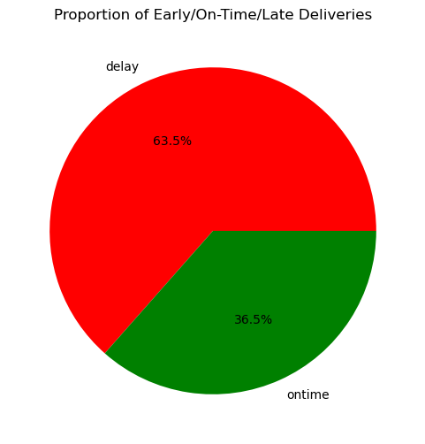

```python
counts = np.array([df['delay'].count(), df['ontime'].count()])
plt.figure(figsize=(6, 6))
plt.pie(counts, labels=["delay", "ontime"], autopct='%1.1f%%', colors=[ 'red', 'green'])
plt.title('Proportion of Early/On-Time/Late Deliveries')
plt.show()
```

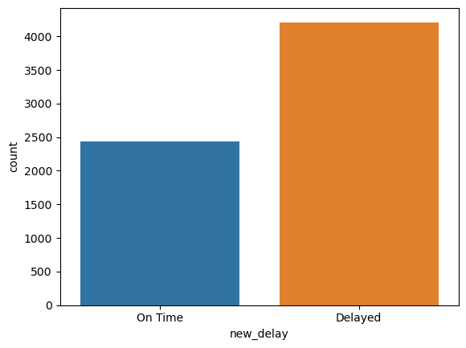

```python
sns.countplot(x = 'new_delay', data=df, hue = 'new_delay')
```

### Delay compared to hours driven

Disclaimer: The "On Time" in the negatives are actually early deliveries

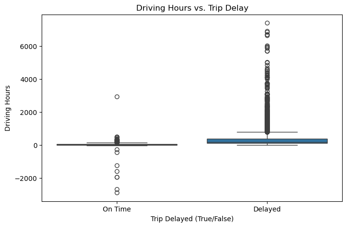

```python
df["driving_hours"] = (pd.to_datetime(df["actual_eta"]) - pd.to_datetime(df["trip_start_date"])).dt.total_seconds() / 3600
df["driving_hours"] = df["driving_hours"]

plt.figure(figsize=(8, 5))
sns.boxplot(x='new_delay', y='driving_hours', data=df)
plt.xlabel("Trip Delayed (True/False)")
plt.ylabel("Driving Hours")
plt.title("Driving Hours vs. Trip Delay")
plt.show()
```

### Delay for customers

As a disclaimer there are over 40+ different customers, some of which only have less than 10 rows. So to make it easier, we'll look at the top 5 with the most rows.

```python
df['customerNameCode'].value_counts().nlargest(20)
```

```
customerNameCode
Larsen & toubro limited                     4066
Ford india private limited                   628
Daimler india commercial vehicles pvt lt     535
Lucas tvs ltd                                206
Ericsson india private limited               201
Ashok leyland limited                        194
Brakes india private ltd                     157
Tvs motor company limited                    108
Wipro enterprises pvt ltd                     74
Otis elevator company (india) ltd             72
Kone elevator india private limited           63
Motherson sumi system ltd                     62
Tvs srichakra limited                         45
Ashok Leyland Limited                         40
Turbo energy pvt ltd                          25
Tractors & farm equipment limited             23
Hero motocorp ltd                             20
Spicer india private ltd                      17
Jindal poly films ltd                         16
Comstar automotive technologies pvt ltd       16
Name: count, dtype: int64
```

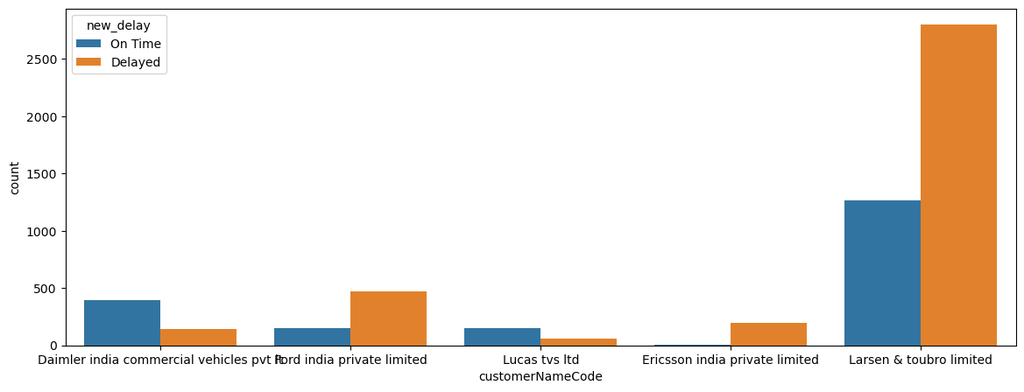

```python
top_5_customers = df['customerNameCode'].value_counts().nlargest(5).index

# Filter the DataFrame to only include those top 5 customers
filtered_df = df[df['customerNameCode'].isin(top_5_customers)]
plt.figure(figsize=(14, 5))
sns.countplot(x=filtered_df['customerNameCode'], data=filtered_df, hue = 'new_delay')
```

Daimler India does show some promising in something different, but it doesn't seem too impressive.

## Market/Regular delays

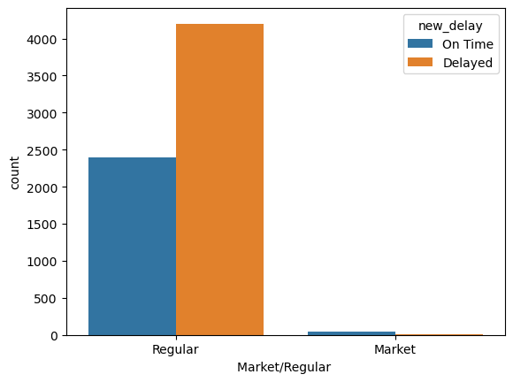

```python
sns.countplot(x = 'Market/Regular ', data=df, hue = 'new_delay')
```

Nothing very intresting sadly :(

### GPS Accuracy

Let's look at some GPS some truckers use and test if they are accurate at predicting the drivers' arrival compared to others. Similar to customers, we'll only be looking at the top five again

```python
df["GpsProvider"].value_counts().nlargest(15)
```

```
GpsProvider
CONSENT TRACK      3726
VAMOSYS             741
EKTA                305
JTECH               238
MANUAL              212
KRC LOGISTICS       166
WDSL                 72
BEECON               33
NUEVASTECH           27
Garuda               24
APACE_TRANSCO        21
SAILOGISTICS         19
FLEETX               19
VIRSTEMPO            14
BALLY LOGISTICS      13
Name: count, dtype: int64
```

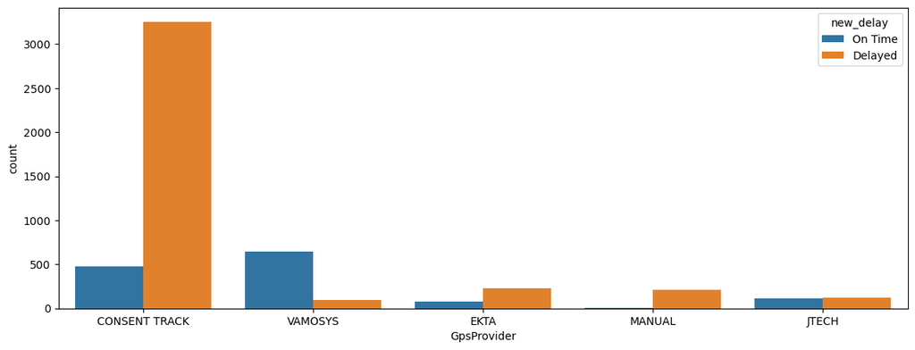

```python
top_5_gps = df['GpsProvider'].value_counts().nlargest(5).index

# Filter the DataFrame to only include those top 5 customers
filtered_df = df[df['GpsProvider'].isin(top_5_gps)]
plt.figure(figsize=(14, 5))
sns.countplot(x=filtered_df['GpsProvider'], data=filtered_df, hue = 'new_delay')
```

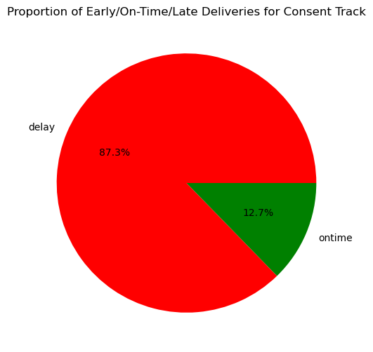

```python
consent_track_data = df[df['GpsProvider'] == 'CONSENT TRACK']
counts = np.array([consent_track_data['delay'].count(), consent_track_data['ontime'].count()])
plt.figure(figsize=(6, 6))
plt.pie(counts, labels=["delay", "ontime"], autopct='%1.1f%%', colors=[ 'red', 'green'])
plt.title('Proportion of Early/On-Time/Late Deliveries for Consent Track')
plt.show()
```

[output not shown]

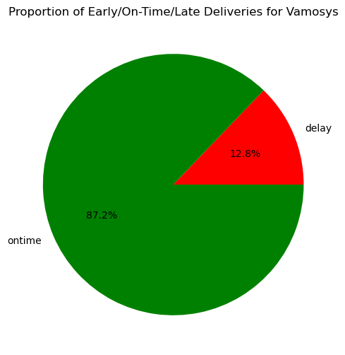

```python
vamosys_data = df[df['GpsProvider'] == 'VAMOSYS']
print(vamosys_data.shape)
counts = np.array([vamosys_data['delay'].count(), vamosys_data['ontime'].count()])
plt.figure(figsize=(6, 6))
plt.pie(counts, labels=["delay", "ontime"], autopct='%1.1f%%', colors=[ 'red', 'green'])
plt.title('Proportion of Early/On-Time/Late Deliveries for Vamosys')
plt.show()
```

## Storytelling

I think mostly all the questions I asked were answered. I do wish I knew how to map the pinged locations to create a visual map, but I had issues with seaborn/matplotlib and visualizing it to be comprehensible. It also doesn't help that the pinged location wasn't in predictable times and there were very few rows with the same people.

Other than that I'm very happy with what I've found. Finding out the current state of delays and working with the above facts has provided some insight surrounding delays and some identifiers for them.

## References

- [Truck Trips Dataset](https://www.kaggle.com/datasets/ramakrishnanthiyagu/delivery-truck-trips-data/data)
- [Introduction facts](https://www.geotab.com/blog/trucking-industry-statistics)